# 从PPT到宣传海报

# 从PPT 到宣传海报：用 WorkBuddy 把办公内容变成图

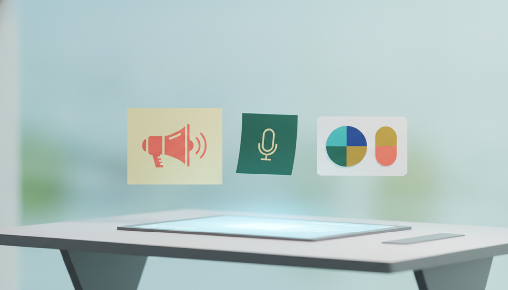

办一场内部分享，文稿写完往往只是第一步。

**接下来你要面对一堆琐碎的“视觉活”：**

- PPT 封面需要一张大气的底图，但左边得空出来写大标题；
- 页面正文需要几个小插画，最好是免抠的透明底，随时能挪动；
- 发在工作群里的通知海报，不仅要有氛围，还得把时间、地点、讲什么写得明明白白；
- 讲到核心方法论，干巴巴的文字没人听，最好能有一张一目了然的三步走示意图。

**这次我们以PPT生图、海报的工作场景来看如何把workbuddy用到极致**

# 一、PPT 配图：先想清楚它要放在哪

同样是“做张配图”，做封面背景和做内页插图，完全是两码事。

封面底图要懂得“克制和留白”，给文字留足空间；而内页小插画则需要干干净净的透明背景，方便在幻灯片里随时挪动。

## 1. 封面底图：把关键位置留给文字

很多 AI 生成的封面背景，画面正中心通常塞满了主体，你想打两行字都没地方放。

所以提要求时，“在哪里留白”比“用什么画风”更重要：明确告诉它主体放右边，左边留出半张画布写标题，并且画内不要自己乱写文字。

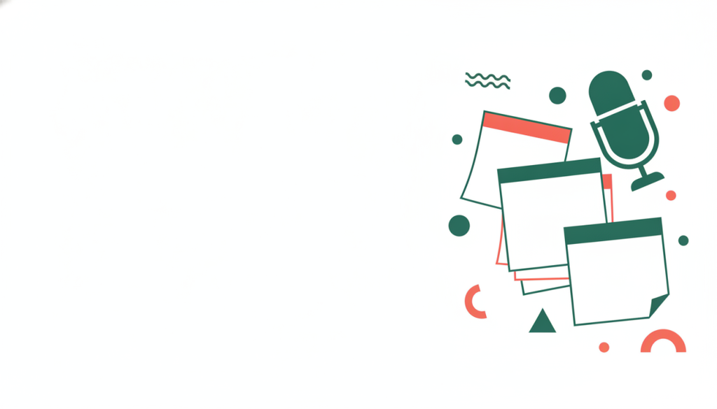

右侧集中装饰、左侧留白的分享会封面底图

> 可复用的提示词：使用nonelinear-image，生成一张公司内部表达分享会的横版封面底图，比例 16:9。 右侧安排话筒、便签和少量几何装饰；左侧留出约一半干净空间，供后续添加文字标题。 风格采用白色背景、深绿色为主配少量珊瑚红，简洁扁平插画风。 画面内不要出现任何文字、数字、Logo 或水印，只生成一张。

如果你想要科幻感的PPT背景，也可以生成：

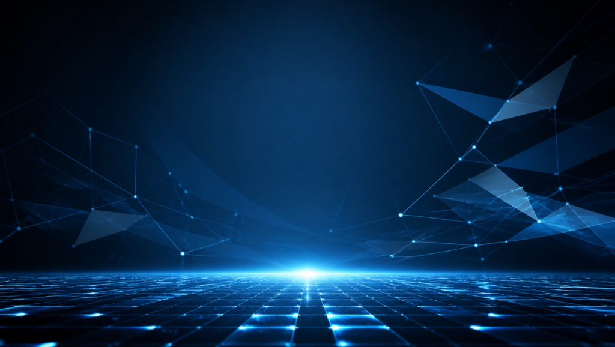

实操小提醒：生成的原图右侧元素丰富，左侧干净通透，直接丢进 PPT 就能打字。但有一个细节需要注意：AI 返回的图片比例有时并非严格的 16:9，比如我们这次拿到的是 1344×768（接近 7:4）。放进全屏幻灯片之前，最好手动裁切或者对齐一下，避免画面被拉伸变形。

## 2. 内容页插画：指定透明 PNG 免抠素材

讲到沟通工具时，我们可能只需要一个小扩音器当点缀。这时不要生成整张带白底的图，直接让 AI 产出带透明通道的 PNG。

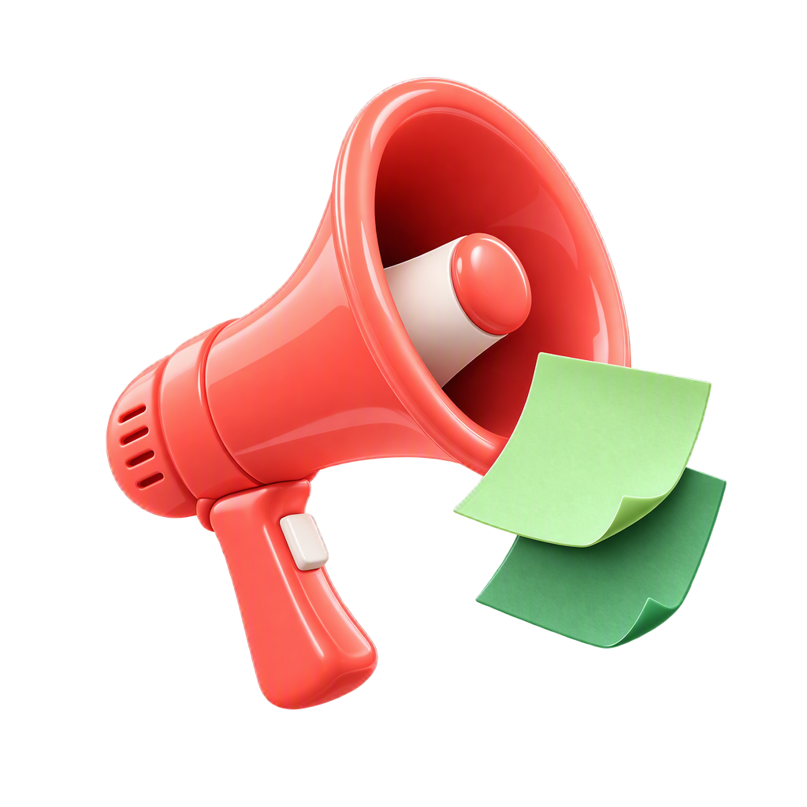

扩音器与便签的透明 PNG 原图

> 可复用的提示词：使用 nonelinear-image，指定 gpt-image-2，生成一张正方形透明背景 PNG 素材。 主体是一只珊瑚红色的立体扩音器，搭配两张深绿色便签，表达“清晰沟通”。 主体完整，边缘干净，不要文字、地面、底座或多余阴影，不要白色或棋盘格背景。 只生成一张。

实操小提醒：实测这张图确实输出了真正的透明通道（Alpha 通道），没有生成那种“假透明”的黑白棋盘格伪背景。 但大家保存时一定要注意：点击下载原始 PNG 文件，千万别在聊天窗口里直接截图，否则截图会自动变成白底，透明效果就白费了。另外，生成的是位图素材，并不是可以拆开编辑颜色的 PPT 矢量形状。

# 二、工作群海报：从“单张图”到“完整图文”

PPT 底图可以留白，但发到工作群里的宣传海报不行。它必须自己把话说明白：这是什么活动？讲什么要点？谁能参加？怎么报名？

第一步：让AI先当文案，梳理信息层级，把原始信息丢给它，先别急着生成画面：

> 我要为公司内部表达分享会做一张工作群宣传海报，请先帮我梳理文案和竖版布局（只给文字方案，暂不生图）：活动名称：把想法讲清楚活动类型：内部表达分享会目标受众：经常做工作汇报、跨部门沟通的同事分享干货：先给结论、补充依据、明确行动时间：9 月 18 日 15:00—16:00地点：三楼会议室报名方式：群内回复“参加”要求：按主标题、核心要点、活动场次信息清晰分层，不要虚构不存在的内容。

第二步：带文字直接生成海报

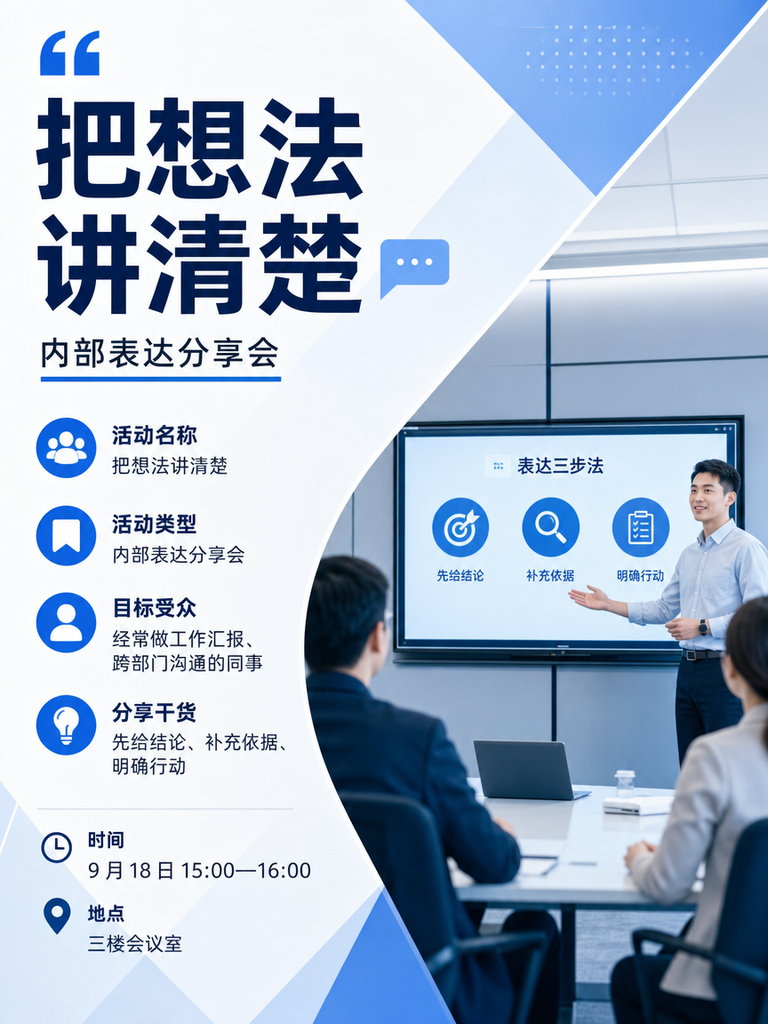

# 三、流程示意图：把抽象逻辑“画”出来

开会做培训时，最怕整页都是大段大段的文字。很多时候，一张理顺逻辑的示意图，比十句话管用。

比如这段常见的工作汇报原则：

> “工作汇报要先给结论，让对方第一时间知道判断；接着补充依据，说明判断怎么来的；最后明确行动，说清谁在什么时间做什么。”

这段话写得挑不出毛病，但放在 PPT 演讲时并不抓人。

我们让AI把这句话提取成具有递进关系的“三步走流程图”

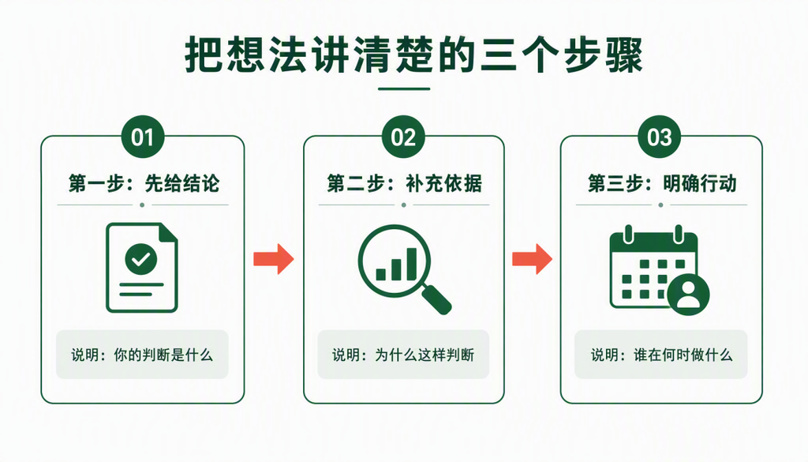

先给结论、补充依据、明确行动的三步培训示意图

> 可复用的提示词：使用 nonelinear-image，指定 gpt-image-2，quality 为 medium，生成一张横版培训示意图，比例 16:9。 标题：把想法讲清楚的三个步骤从左到右依次排列三个步骤：第一步：先给结论（说明：你的判断是什么）第二步：补充依据（说明：为什么这样判断）第三步：明确行动（说明：谁在何时做什么）结构要求：三个横向分区清晰，用单向箭头从左至右串联，保留全部说明文字。 视觉风格：白色背景，深绿为主色，珊瑚红用于强化箭头流向。画面干净极简，不要多余分支或图表装饰，生成一张。

[figure not shown]

使用这类示意图要把握好边界：它非常适合用来解释概念框架、演讲三步法、轻量方法论；但如果涉及严格的业务审批分支、精密数据图表，或者后续需要频繁修改文案的项目，还是老老实实手绘矢量流程图或用 Excel 做表更靠谱。毕竟 AI 生成的是一张完整图片，后期想改动其中一个字，就只能重新生成整张图了。

但你的一个模糊的想法，都可以输入给他，比如以“把想法讲清楚”输出逻辑图，看看他的出品给到你参考：

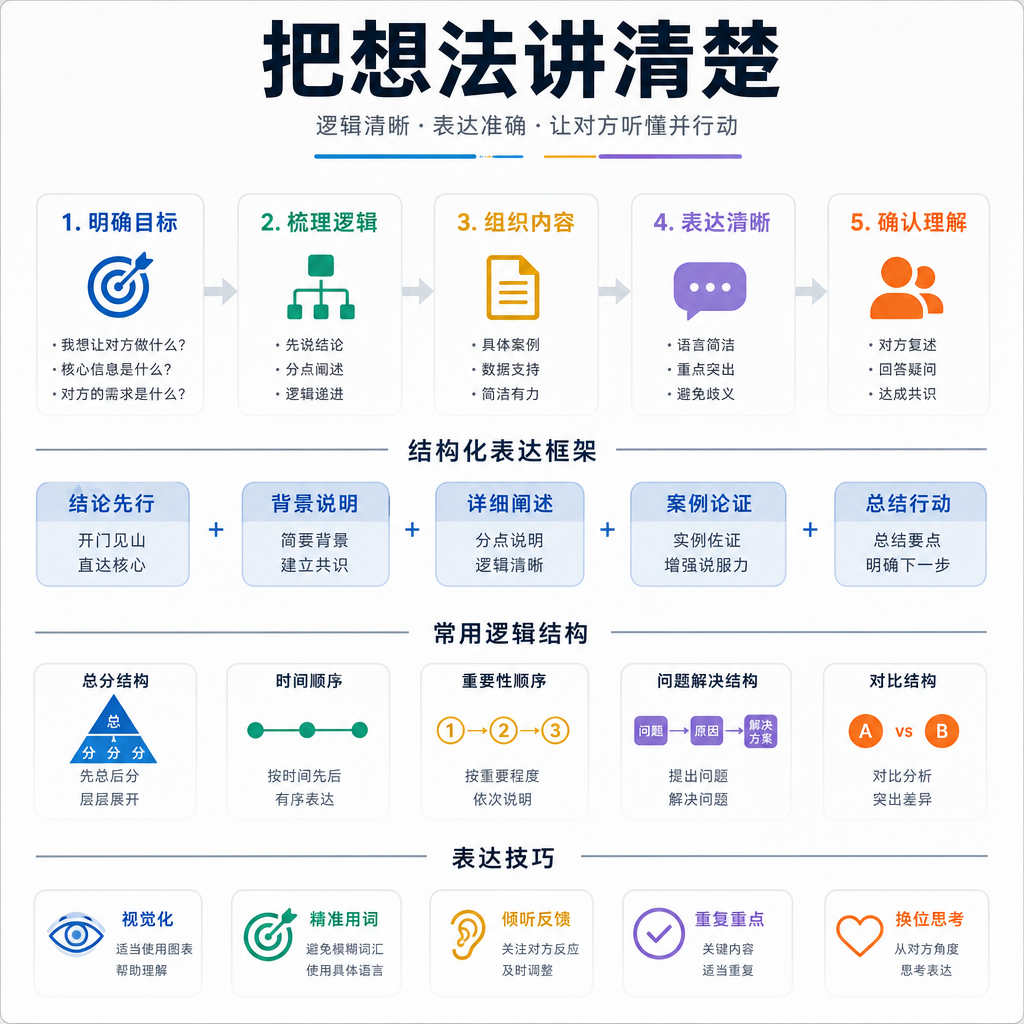

# 四、经验总结：把需求说清，把结果看准

跑完这几个任务，你会发现 AI 做图其实有一套通用的思路：不要指望一句“帮我做张图”搞定一切，而是先明确角色，再给足约束。

我们可以把不同场景下的关注重点拉一张清单：

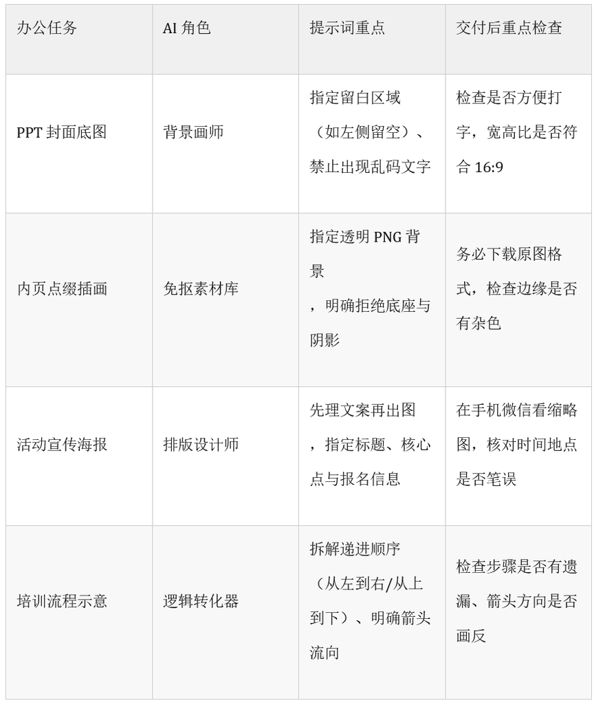

如果你也想在WorkBuddy里体验这套生图工作流，在**https://github.com/Fitnessnlp/nonelinear-skills/releases**项目地址下载安装成为Skill。当然，你直接让Workbuddy按照上述地址安装也行，新用户免费送做50-100张图

[figure not shown]

在下次做 PPT 或群海报前，不妨照着文中的提示词模版试一试。

**快来试试吧！**

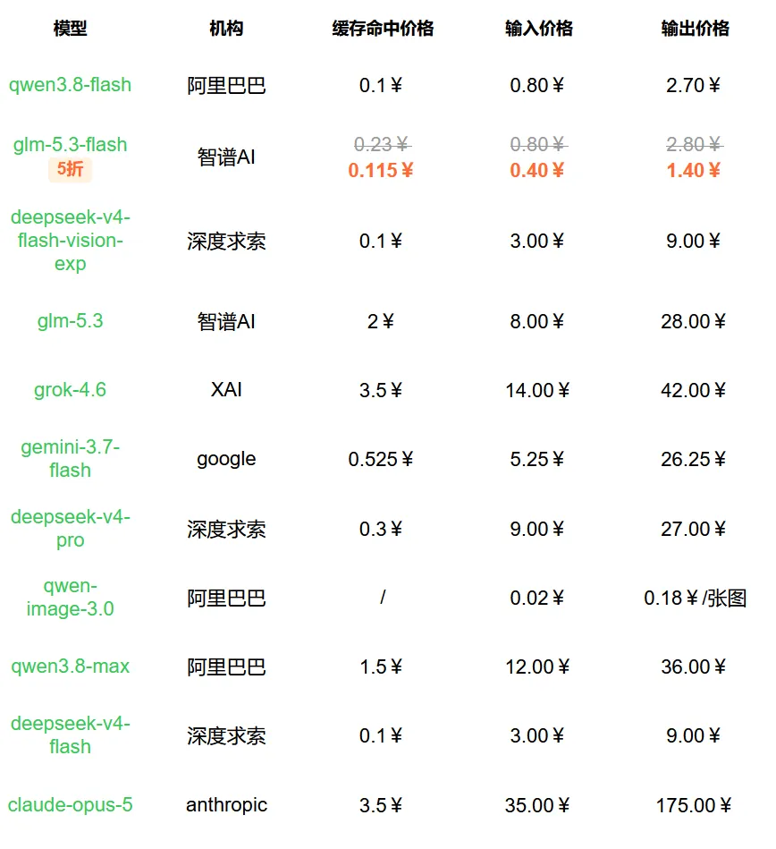

**非线智能**

**Nonelinear**

9月20日前新用户

**免费送50-100张图**

充 值

** 5000 送500**

全部模型，折扣共享

[figure not shown]

📎 **原始 Word 文件**：03-从PPT到宣传海报.docx